# Cours 7 ACT3035

Ceci est un cours pour introduire les concepts et syntaxe du R Markdow avec un exemple concret de régression linéaire. Le matériel nécessaire pour la syntaxe se trouve dans [ACT3035](https://nmeraihi.github.io/act3035book/sommaire.html).

Pour débuter avec cet exemple concret, allons chercher les donnes `flight_delay.csv` dans le repo [ACT3035H24](https://github.com/nmeraihi/ACT3035/tree/master/HIV_2024).

## Ecploration des données

Nous allons essayer de prédire les retards d’avions en appliquant une régression lin multiple sur les données `flight_delay.csv` de type $y_{i}=\beta _{0}+\beta _{1}x_{i1}+\cdots +\beta _{p}x_{ip}+\varepsilon _{i}=\mathbf {x} _{i}^{\mathsf {T}}{\boldsymbol {\beta }}+\varepsilon _{i}$

```r
data1 <- read.csv("https://raw.githubusercontent.com/nmeraihi/ACT3035/master/HIV_2024/flight_delay.csv")
```

Rgegardons ensuite les première observations des ces données

```r
head(data1)
```

|  | Carrier | Airport_Distance | Number_of_flights | Weather | Support_Crew_Available | Baggage_loading_time | Late_Arrival_o | Cleaning_o | Fueling_o | Security_o | Arr_Delay |
| --- | --- | --- | --- | --- | --- | --- | --- | --- | --- | --- | --- |
| 1 | UA | 437 | 41300 | 5 | 83 | 17 | 19 | 15 | 26 | 31 | 58 |
| 2 | UA | 451 | 41516 | 5 | 82 | 17 | 19 | 15 | 22 | 32 | 48 |
| 3 | AA | 425 | 37404 | 5 | 175 | 16 | 17 | 14 | 28 | 29 | 16 |
| 4 | B6 | 454 | 44798 | 6 | 49 | 18 | 19 | 13 | 29 | 31 | 81 |
| 5 | DL | 455 | 40643 | 6 | 55 | 17 | 19 | 18 | 26 | 37 | 62 |
| 6 | UA | 416 | 39707 | 5 | 146 | 16 | 19 | 6 | 28 | 31 | 34 |

Maintenant regardons quelles sont les dimensions de ce jeux de données:

```r
dim(data1)
```

```
## [1] 3593   11
```

affichons les statistiques descriptives de la variable réponse `Arr_Delay`:

```r
summary(data1$Arr_Delay)
```

```
##    Min. 1st Qu.  Median    Mean 3rd Qu.    Max.
##     0.0    49.0    70.0    69.8    90.0   180.0
```

Regardons la corrélation **Pearson** des deux variables `Arr_Delay` et `Number_of_flights`.

```r
corr <- cor.test(data1$Arr_Delay, data1$Number_of_flights, method = "pearson")
corr
```

```
##
##  Pearson's product-moment correlation
##
## data:  data1$Arr_Delay and data1$Number_of_flights
## t = 86.823, df = 3591, p-value < 2.2e-16
## alternative hypothesis: true correlation is not equal to 0
## 95 percent confidence interval:
##  0.8121611 0.8332786
## sample estimates:
##      cor
## 0.823004
```

On voit bien qu’il existe une forte corrélation de l’orde de 0.823 entre nos deux variable d’intérêt Arr_Delay`et`Number_of_flights`

## Graphiques

Allons maintenant tracer quelques graphiques de type nuage de points sur la variable dépondantes avec d’autres variable dans mon jeu de données.

### Arr_Delay vs Number_of_flights

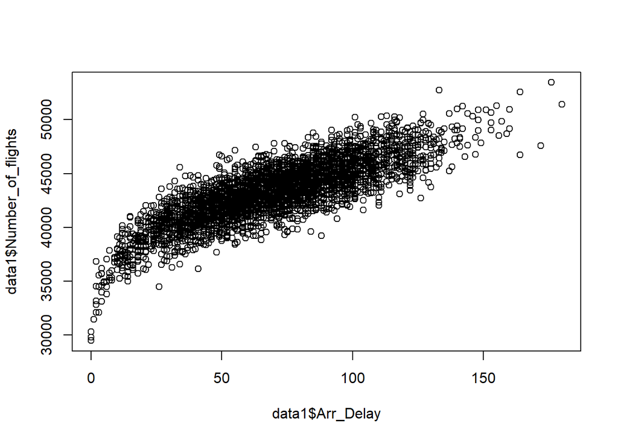

```r
plot(data1$Arr_Delay, data1$Number_of_flights)
```

### Arr_Delay vs Security_o

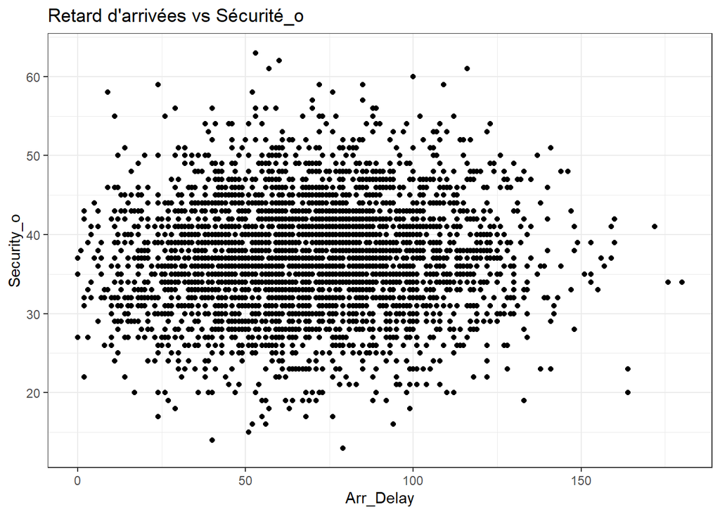

```r
ggplot(data1, aes(x=Arr_Delay, y=Security_o))+
  geom_point()+
  theme_bw()+
  ggtitle("Retard d'arrivées vs Sécurité_o")
```

### Arr_Delay vs Support_Crew_Available

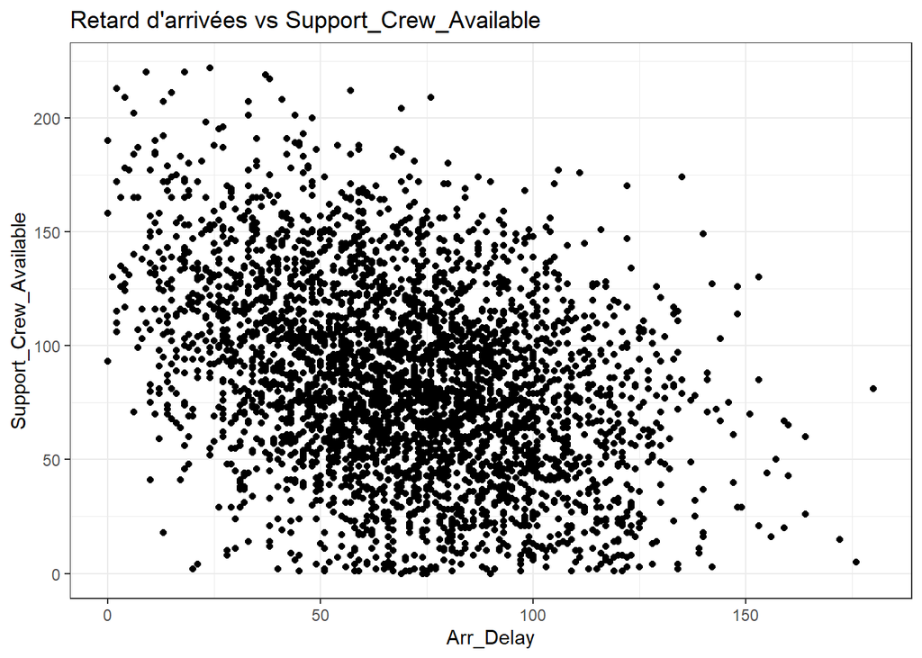

```r
ggplot(data1, aes(x=Arr_Delay, y=Support_Crew_Available))+
  geom_point()+
  theme_bw()+
  ggtitle("Retard d'arrivées vs Support_Crew_Available")
```

### Arr_Delay vs Airport_Distance

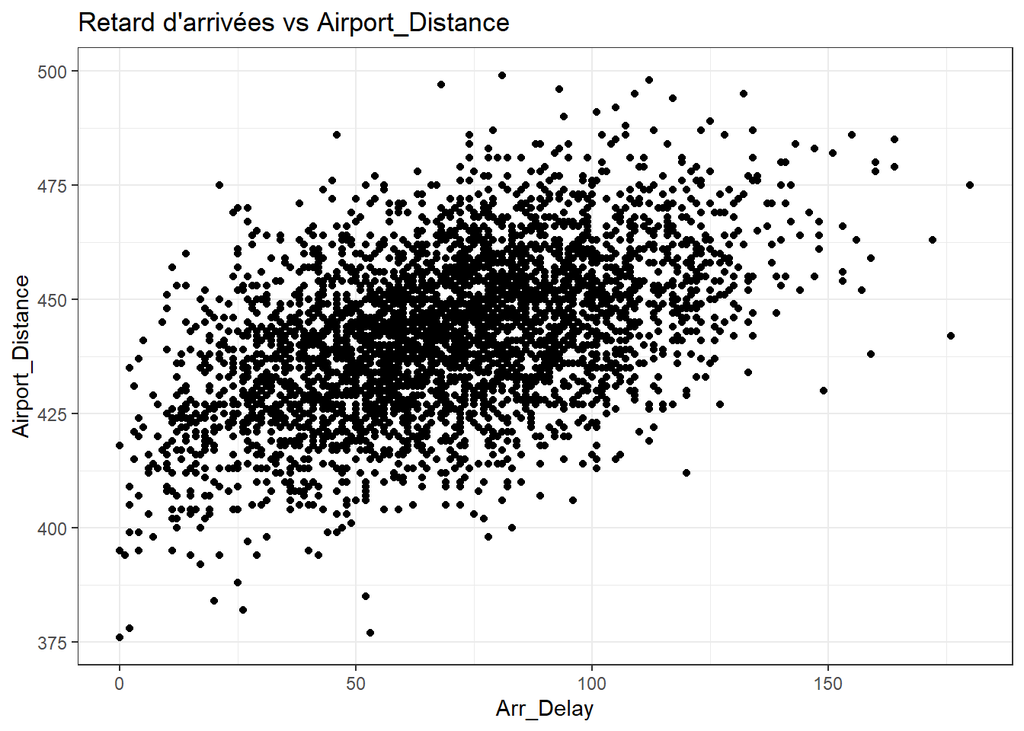

```r
ggplot(data1, aes(x=Arr_Delay, y=Airport_Distance))+
  geom_point()+
  theme_bw()+
  ggtitle("Retard d'arrivées vs Airport_Distance")
```

## Modéliation

Supprimons d’abord la première variable `Carrier` et copions je de données dans un autre *data frame* appelé `data2`.

```r
data2 <- data1[-c(1)]
```

Regardons donc les première observations de ce jeu données:

```r
head(data2)
```

|  | Airport_Distance | Number_of_flights | Weather | Support_Crew_Available | Baggage_loading_time | Late_Arrival_o | Cleaning_o | Fueling_o | Security_o | Arr_Delay |
| --- | --- | --- | --- | --- | --- | --- | --- | --- | --- | --- |
| 1 | 437 | 41300 | 5 | 83 | 17 | 19 | 15 | 26 | 31 | 58 |
| 2 | 451 | 41516 | 5 | 82 | 17 | 19 | 15 | 22 | 32 | 48 |
| 3 | 425 | 37404 | 5 | 175 | 16 | 17 | 14 | 28 | 29 | 16 |
| 4 | 454 | 44798 | 6 | 49 | 18 | 19 | 13 | 29 | 31 | 81 |
| 5 | 455 | 40643 | 6 | 55 | 17 | 19 | 18 | 26 | 37 | 62 |
| 6 | 416 | 39707 | 5 | 146 | 16 | 19 | 6 | 28 | 31 | 34 |

```r
dimension <- dim(data2)
```

Nous avons donc maintenant 3593 obesrvations sur 10 variables.

### Division des données

Nous allons maintenant diviser nos données en deux parties, soient un échantillons aléatoire afin d’ajuster le modèle de régression liné multiples. L’autres partie restante des données, servira à tester la performance de notre modèle.

Pour cela, nous avons besoin d’un *package* appelé `caTools`

Afin de répéter cette expérience avec les mêmes résultats, nous allons fixer notre seed à 3035.

```r
set.seed(3035)
```

Faisons un tirage aléatoire de 70% des observations de la variable réponse `Arr_Delay`. Cette échantillonage nous servira a diviser toutes les données en deux partie; 70% des données de data2 sera alloué à entraîner le modèle. La partie restante (30%) servira à tester le modèle.

```r
sample <- caTools::sample.split(data2$Arr_Delay, SplitRatio = .70)
train_data <- subset(data2, sample==T)
test_data <- subset(data2, sample==F)
```

Ajustons un premier modèle apelé `model` sur toutes les données `train_data`.

```r
model <- lm(Arr_Delay~., data = train_data)
```

Voici un apperçu sommaire du modèle:

```r
summary(model)
```

```
##
## Call:
## lm(formula = Arr_Delay ~ ., data = train_data)
##
## Residuals:
##     Min      1Q  Median      3Q     Max
## -37.177  -8.390  -0.479   8.247  69.314
##
## Coefficients:
##                          Estimate Std. Error t value Pr(>|t|)
## (Intercept)            -5.762e+02  9.039e+00 -63.752  < 2e-16 ***
## Airport_Distance        1.650e-01  1.625e-02  10.152  < 2e-16 ***
## Number_of_flights       4.480e-03  1.295e-04  34.601  < 2e-16 ***
## Weather                 5.172e+00  5.411e-01   9.559  < 2e-16 ***
## Support_Crew_Available -4.846e-02  6.382e-03  -7.594 4.36e-14 ***
## Baggage_loading_time    1.300e+01  5.238e-01  24.822  < 2e-16 ***
## Late_Arrival_o          7.113e+00  3.949e-01  18.015  < 2e-16 ***
## Cleaning_o             -2.213e-03  7.217e-02  -0.031    0.976
## Fueling_o               3.560e-02  7.140e-02   0.499    0.618
## Security_o              1.555e-02  3.562e-02   0.437    0.662
## ---
## Signif. codes:  0 '***' 0.001 '**' 0.01 '*' 0.05 '.' 0.1 ' ' 1
##
## Residual standard error: 12.45 on 2504 degrees of freedom
## Multiple R-squared:  0.8195, Adjusted R-squared:  0.8188
## F-statistic:  1263 on 9 and 2504 DF,  p-value: < 2.2e-16
```

Nous remarquons que certaines variales, comme `Cleaning_o`, `Fueling_o` et `Security_o` ne sont pas significatives selon la *P value*, nous allons donc les exclure du modèle amélioré.

```r
model_amélioré <- lm(Arr_Delay~Airport_Distance+Number_of_flights+Weather+Support_Crew_Available+Baggage_loading_time+Late_Arrival_o, data=train_data)
```

regardons maintenant un apperçu de ce nouveau modèle:

```r
summary(model_amélioré)
```

```
##
## Call:
## lm(formula = Arr_Delay ~ Airport_Distance + Number_of_flights +
##     Weather + Support_Crew_Available + Baggage_loading_time +
##     Late_Arrival_o, data = train_data)
##
## Residuals:
##     Min      1Q  Median      3Q     Max
## -37.221  -8.410  -0.538   8.196  69.315
##
## Coefficients:
##                          Estimate Std. Error t value Pr(>|t|)
## (Intercept)            -5.751e+02  8.782e+00 -65.484  < 2e-16 ***
## Airport_Distance        1.649e-01  1.624e-02  10.152  < 2e-16 ***
## Number_of_flights       4.478e-03  1.292e-04  34.655  < 2e-16 ***
## Weather                 5.175e+00  5.408e-01   9.569  < 2e-16 ***
## Support_Crew_Available -4.837e-02  6.372e-03  -7.591 4.43e-14 ***
## Baggage_loading_time    1.302e+01  5.225e-01  24.927  < 2e-16 ***
## Late_Arrival_o          7.114e+00  3.942e-01  18.049  < 2e-16 ***
## ---
## Signif. codes:  0 '***' 0.001 '**' 0.01 '*' 0.05 '.' 0.1 ' ' 1
##
## Residual standard error: 12.44 on 2507 degrees of freedom
## Multiple R-squared:  0.8194, Adjusted R-squared:  0.819
## F-statistic:  1896 on 6 and 2507 DF,  p-value: < 2.2e-16
```

Regardons comment le modèle prédit les valeurs sur les données d’entrainement:

```r
pred_train <- model_amélioré$fitted.values
head(pred_train)
```

```
##         1         3         5         7         8         9
## 60.352362  9.225622 66.907535 64.229115 47.759742 71.641443
```

Regardons comment mon modèle performe sur les données cachées (test_data). Pour ce faire, nous allons comparer ce que nous avons observer dans ce jeu de données avev ce qui sera prédit par le modèle_améioré qui a été entrainé sur les data_train.

```r
pred_test <- predict(model_amélioré, newdata = test_data)
```

Insérons ces prédictions dans un nouveau data frame appelé `pred_test_df`.

```r
pred_test_df <- data.frame(pred_test)
```

Regardons les données observées de l’échantilon test vs les prédiction.

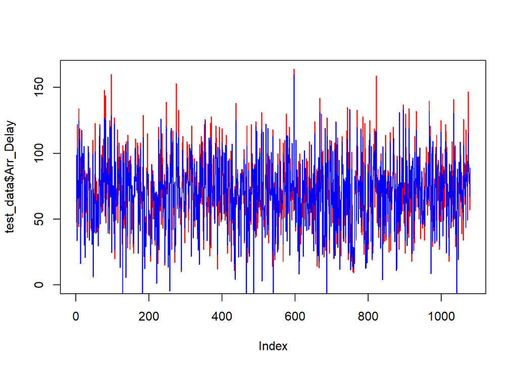

```r
plot(test_data$Arr_Delay, col="red", type="l")
lines(pred_test_df, col="blue", type="l")
```

ceci est un exemple du code Latex si on veux écrire l’infini $\infty$ à $\infty$